# Construcción de Modelos - Chapter 24

## Variables calculadas

Si estas experimentando con muchos modelos y muchas visualizaciones, es una buena idea agrupar la creación de variables en una función para que no haya posibilidad de aplicar accidentalmente transformaciones a diferentes lugares. Por ejemplo, podríamos escribir:

```r
compute_vars <- function(data) {
  data %>%
    mutate(
      trimestre = trimestre(date),
      dia_semana = wday(date, label = TRUE)
    )
}
```

Otra opción es colocar las transformaciones directamente en la fórmula del modelo:

```r
dia_semana2 <- function(x) wday(x, label = TRUE)
mod3 <- lm(n ~ dia_semana2(fecha) * trimestre(fecha), data = vuelos_por_dia)
```

Cualquiera de los enfoques es razonable. Hacer que una variable transformada sea explicita es útil si quieres verificar tu trabajo, o usarlas en una visualización. Pero no puedes usar fácilmente transformaciones (como splines) que devuelven múltiples columnas. Incluir las transformaciones en el modelo hace la vida más fácil cuando se trabaja con diferentes conjuntos de datos porque el modelo es autónomo.

## Época del año: un enfoque alternativo

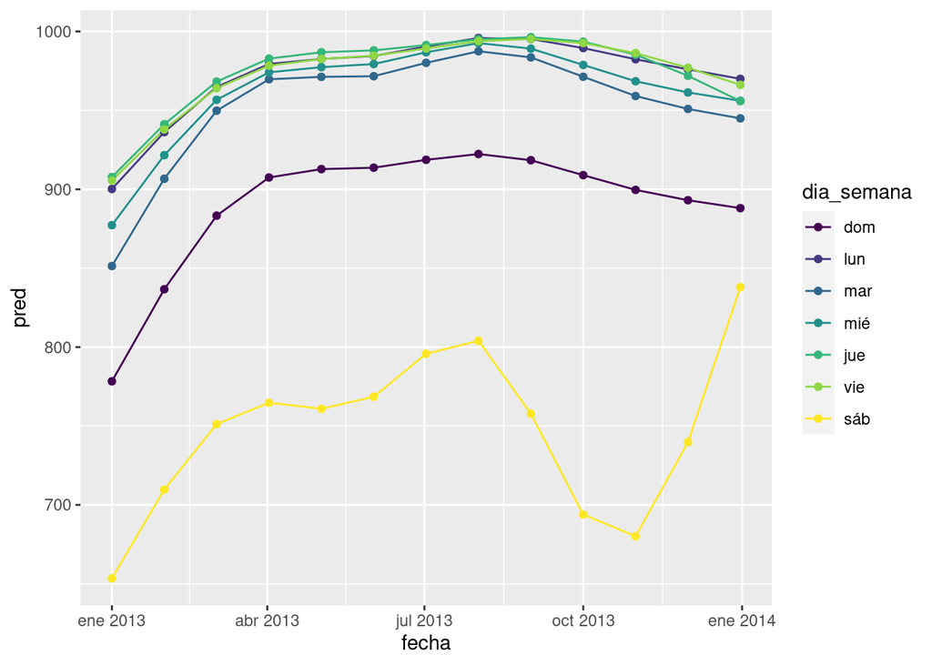

```r
library(splines)
mod <- MASS::rlm(n ~ dia_semana * ns(fecha, 5), data = vuelos_por_dia)

vuelos_por_dia %>%
  data_grid(dia_semana, fecha = seq_range(fecha, n = 13)) %>%
  add_predictions(mod) %>%
  ggplot(aes(fecha, pred, colour = dia_semana)) +
    geom_line() +
    geom_point()
```

Vemos un patrón fuerte en el número de vuelos de los sábados. Esto es tranquilizador, porque también vimos ese patrón en los datos sin transformar. Es una buena señal cuando obtienes la misma señal desde diferentes enfoques.